# Brazil State and Region Level Data - 22/06/2020

James Hunter, PhD, EPM, UNIFESP

22 June 2020

> **Internal Use Only**

# Brazil Covid-19 Data

File will be converted from .xlsx to .csv in Excel so `data.table::fread()` can be used.

```r
filename <- here::here("data/HIST_PAINEL_COVIDBR_21jun2020.csv") # ALWAYS Check the name!

region_names <- tibble(pt = c("Norte", "Nordeste", "Sudeste", "Sul",
                              "Centro-Oeste"),
                       region_en = c("North", "Northeast", "Southeast", "South",
                                     "Center-West"))
state_names <- tibble(sigla = c("AC", "AL", "AM", "AP", "BA", "CE", "DF", "ES",
                                "GO", "MA", "MG", "MS", "MT", "PA", "PB", "PE",
                                "PI", "PR", "RJ", "RN", "RO", "RR", "RS", "SC",
                                "SE", "SP", "TO"),
                      state_name = c("Acre", "Alagoas", "Amazonas", "Amapá",
                                     "Bahia", "Ceará", "Distrito Federal",
                                     "Espírito Santo", "Goiás", "Maranhão",
                                     "Minas Gerais", "Mato Grosso do Sul",
                                     "Mato Grosso", "Pará", "Paraíba",
                                     "Pernambuco", "Piauí", "Paraná",
                                     "Rio de Janeiro", "Rio Grande do Norte",
                                     "Rondônia", "Roraima", "Rio Grande do Sul",
                                     "Santa Catarina", "Sergipe", "São Paulo",
                                     "Tocantins"))
```

Load the data file using `data.table::fread()`.

```r
br_data <- fread(filename)

br_data <- br_data %>%
  select(reg = regiao, st = estado, mun = municipio, date = data,
         pop = populacaoTCU2019, cases_accum = casosAcumulado,
         cases_new = casosNovos, deaths_accum = obitosAcumulado,
         deaths_new = obitosNovos) %>%
  mutate(pop = as.numeric(pop)) %>%  # make pop numeric
  mutate(date_d = as.Date(date, format = "%m/%d/%Y")) # put dates in calculable

# Clean region and state names

br_data <- br_data %>%
  left_join(state_names, by = c("st" = "sigla"))

#saveRDS(br_data, here(glue("data/", "br_data_160621.rds")))  # use to save data
```

# Exploratory Data Analysis - Tables and Summaries

The first table shows the overall summary measures for the variables to find any inconsistent values or values that need to be examined.

```r
date_first_case <- ymd("2020/02/26")

date_first_death <- ymd("2020/03/17")

date_last <- mdy(br_data$date[nrow(br_data)])

num_dates <- date_last - date_first_case

br_data %>%
  select(-pop) %>%
  summarytools::descr(stats = "common")
```

```
## Descriptive Statistics
## br_data
## N: 436129
##
##                   cases_accum   cases_new   deaths_accum   deaths_new
## --------------- ------------- ----------- -------------- ------------
##            Mean        177.40        7.46           9.82         0.35
##         Std.Dev       6485.91      252.26         350.62        11.03
##             Min          0.00    -1370.00           0.00       -36.00
##          Median          1.00        0.00           0.00         0.00
##             Max    1085038.00    54771.00       50617.00      1473.00
##         N.Valid     436129.00   436129.00      436129.00    436129.00
##       Pct.Valid        100.00      100.00         100.00       100.00
```

## Apparent Reclassification of Cases and Deaths away from COVID-19

As can be seen, there are two issues with the data. Both `cases_new` and `deaths_new` have negative values for the minimum value. This must mean that the Ministry has reclassified some cases and deaths as not being related to COVID-19. Next, I will create a table of those days and geographic regions that registered these negative values to see if a pattern exists.

```r
neg_mins <- br_data %>%
  filter(cases_new < 0 | deaths_new < 0) %>%
  select(reg, st, state_name, mun, date, cases_new, deaths_new)
glimpse(neg_mins)
```

```
## Rows: 4,749
## Columns: 7
## $ reg        <chr> "Norte", "Norte", "Norte", "Norte", "Norte", "Norte", "N...
## $ st         <chr> "RO", "RO", "RO", "RO", "RO", "RO", "RO", "RO", "RO", "R...
## $ state_name <chr> "Rondônia", "Rondônia", "Rondônia", "Rondônia", "Rondôni...
## $ mun        <chr> "", "", "", "Alta Floresta D'Oeste", "Alta Floresta D'Oe...
## $ date       <chr> "4/24/2020", "5/1/2020", "5/17/2020", "5/9/2020", "5/24/...
## $ cases_new  <int> -7, -4, -2, -1, -1, -8, -4, -5, -1, -1, -1, -1, -1, -2, ...
## $ deaths_new <int> 0, 0, 0, 0, 0, 0, 0, 0, 0, 0, 0, 0, -1, 0, 0, 0, 0, 0, 0...
```

```r
# What states have these negative values
st_neg_vals <- unique(neg_mins$state_name)
```

All the states, except for the Distrito Federal, have these negative values: Rondônia, Acre, Amazonas, Roraima, Pará, Amapá, Tocantins, Maranhão, Piauí, Ceará, Rio Grande do Norte, Paraíba, Pernambuco, Alagoas, Sergipe, Bahia, Minas Gerais, Espírito Santo, Rio de Janeiro, São Paulo, Paraná, Santa Catarina, Rio Grande do Sul, Mato Grosso do Sul, Mato Grosso, Goiás.

We will look to see if they are concentrated in specific dates.

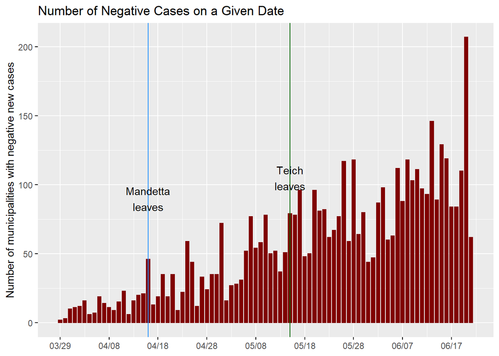

```r
# use summarize to count the number of negative values per given date to find a pattern?
# need to filter out state only numbers (is.na(mun)) to avoid double counting
date_neg_vals <- neg_mins %>%
  filter(!is.na(mun)) %>%
  group_by(date) %>%
  summarise(negs_by_date = n()) %>%
  ungroup()

# Make a bar chart to see if there is a pattern to when these negative values occur

gr_neg_mins <- date_neg_vals %>%
  mutate(date = mdy(date)) %>%
  ggbarplot(x = "date",
         y = "negs_by_date",
         color = "#800000FF",
         fill = "#800000FF",
         palette = "uchicago",
         title = "Number of Negative Cases on a Given Date",
         xlab = FALSE,
         ylab = "Number of municipalities with negative new cases",
         ggtheme = theme_grey()) +
  scale_x_date(date_breaks = "10 days", date_labels = "%m/%d") +
  geom_vline(xintercept = as.Date("2020-04-16"), color = "dodgerblue")+
  annotate("text", label = "Mandetta\nleaves", x = as.Date("2020-04-16"),
           y = 90) +
  geom_vline(xintercept = as.Date("2020-05-15"), color = "darkgreen") +
  annotate("text", label = "Teich\nleaves", x = as.Date("2020-05-15"),
           y = 105)

gr_neg_mins
```

## Inconsistency in Reporting of Cases and Deaths at State Level

When we accumulate the data to get state totals for any given date, there has appeared another inconsistency that the Ministry has not addressed and could be causing a further undercount of cases and deaths. The standard data format for the file includes a field for population, as noted above. The standard way the file gives a statewide total for a given day is to leave the municipality field (`mun`) blank, i.e., with the missing data value`NA`. So, for June, the statewide values for Alagoas appear in the following record:

```r
br_data %>%
  filter(st == "AL" & date == "6/21/2020" & mun == "") %>%
  select(st, mun, date:deaths_new) %>%
  kable(caption = "Data for June for Alagoas (AL)")
```

Data for June for Alagoas (AL)

| st | mun | date | pop | cases_accum | cases_new | deaths_accum | deaths_new |
| --- | --- | --- | --- | --- | --- | --- | --- |
| AL |  | 6/21/2020 | 3337357 | 28657 | 959 | 884 | 18 |
| AL |  | 6/21/2020 | NA | 91 | 3 | 6 | 0 |

These values in the table for the most recent date (6/21/20) tally with the values published for Alagoas on that day as shown on the MoS COVID-19 site only for the line that shows a non-zero population for the state.

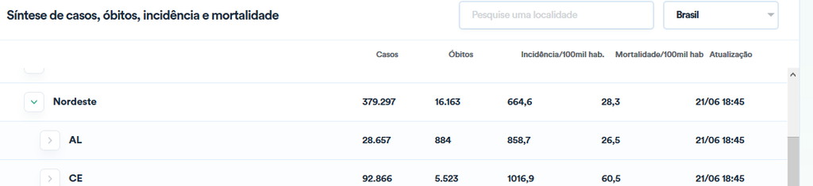

However, there is a second line that meets the search requirement for statewide data, but with the population value missing.

```r
br_data %>%
  filter(st == "AL" & date == "6/21/2020" & mun == "" & is.na(pop)) %>%
  select(st, mun, date:deaths_new)
```

| st | mun | date | pop | cases_accum | cases_new | deaths_accum | deaths_new |
| --- | --- | --- | --- | --- | --- | --- | --- |
| AL |  | 6/21/2020 | NA | 91 | 3 | 6 | 0 |

It is not at all clear what the 91 total cases and 6 total deaths on this line refer to. If it were to a municipality, that field would have a value. If it is statewide, then why is it not included in the first line? The lack of a population value in the case of some municipalities makes sense as the government may not have an accurate value for population. However, when considering the statewide total, the lack of population value does not make sense since it was used in the previous line.

More important, these cases in the second line are **not** included in the statewide totals that the Ministry uses. This could be a programming mistake when generating the table. Whatever the reason, it is not clear whether these 91 cases in Alagoas are an undercount that should have been included in the statewide number of cases.

```r
miss_pop_cases <- br_data %>% filter(is.na(pop) & reg != "Brasil" & mun == "")
miss_pop_states <- length(unique(miss_pop_cases$st))
miss_pop_tot <- nrow(miss_pop_cases)
```

# Summaries of the Data by Date and State

With these doubts as background, we can proceed to examine the cases and deaths by date, state and national region.

```r
# Date summaries

br_data %>%
  filter(date_d >= date_first_case & reg == "Brasil") %>%
  select(date, cases_new, deaths_new) %>%
  kable(caption = "COVID-19 Cases & Deaths by Date for Brazil",
        col.names = c("Date", "Total Cases", "Total Deaths")) %>%
  kable_styling(bootstrap_options = "striped",
                full_width = FALSE)
```

COVID-19 Cases & Deaths by Date for Brazil

| Date | Total Cases | Total Deaths |
| --- | --- | --- |
| 2/26/2020 | 1 | 0 |
| 2/27/2020 | 0 | 0 |
| 2/28/2020 | 0 | 0 |
| 2/29/2020 | 1 | 0 |
| 3/1/2020 | 0 | 0 |
| 3/2/2020 | 0 | 0 |
| 3/3/2020 | 0 | 0 |
| 3/4/2020 | 1 | 0 |
| 3/5/2020 | 4 | 0 |
| 3/6/2020 | 6 | 0 |
| 3/7/2020 | 6 | 0 |
| 3/8/2020 | 6 | 0 |
| 3/9/2020 | 0 | 0 |
| 3/10/2020 | 9 | 0 |
| 3/11/2020 | 18 | 0 |
| 3/12/2020 | 25 | 0 |
| 3/13/2020 | 21 | 0 |
| 3/14/2020 | 23 | 0 |
| 3/15/2020 | 79 | 0 |
| 3/16/2020 | 34 | 0 |
| 3/17/2020 | 57 | 1 |
| 3/18/2020 | 137 | 3 |
| 3/19/2020 | 193 | 2 |
| 3/20/2020 | 283 | 5 |
| 3/21/2020 | 224 | 7 |
| 3/22/2020 | 418 | 7 |
| 3/23/2020 | 345 | 9 |
| 3/24/2020 | 310 | 12 |
| 3/25/2020 | 232 | 11 |
| 3/26/2020 | 482 | 20 |

[output cut: 87 more lines]

```r
# State summaries

br_data %>%
  filter(date_d >= date_first_case & reg != "Brasil" & mun == "") %>%
  group_by(state_name) %>%
  summarise(cumulative_cases = sum(cases_new),
            cumulative_deaths = sum(deaths_new)) %>%
  arrange(desc(cumulative_cases)) %>%
  kable(caption = "COVID-19 Cases & Deaths by State",
        col.names = c("Date", "Total Cases", "Total Deaths")) %>%
  kable_styling(bootstrap_options = "striped",
                full_width = FALSE)
```

COVID-19 Cases & Deaths by State

| Date | Total Cases | Total Deaths |
| --- | --- | --- |
| São Paulo | 219221 | 12588 |
| Rio de Janeiro | 96133 | 8875 |
| Ceará | 94667 | 5523 |
| Pará | 84654 | 4583 |
| Maranhão | 70059 | 1721 |
| Amazonas | 63410 | 2657 |
| Pernambuco | 52230 | 4260 |
| Bahia | 47254 | 1396 |
| Paraíba | 36784 | 766 |
| Espírito Santo | 35273 | 1331 |
| Distrito Federal | 33227 | 423 |
| Alagoas | 28748 | 890 |
| Minas Gerais | 28076 | 680 |
| Amapá | 21840 | 359 |
| Rio Grande do Sul | 19349 | 435 |
| Rio Grande do Norte | 19346 | 703 |
| Sergipe | 18985 | 462 |
| Santa Catarina | 17846 | 246 |
| Goiás | 15619 | 303 |
| Rondônia | 15181 | 417 |
| Paraná | 14666 | 460 |
| Piauí | 14264 | 485 |
| Acre | 11381 | 300 |
| Mato Grosso | 9558 | 366 |
| Tocantins | 8354 | 175 |
| Roraima | 8229 | 253 |
| Mato Grosso do Sul | 5237 | 45 |

```r
# Region summaries

br_data %>%
  filter(date_d >= date_first_case & reg != "Brasil" & mun == "") %>%
  group_by(reg) %>%
  summarise(cumulative_cases = sum(cases_new),
            cumulative_deaths = sum(deaths_new)) %>%
  arrange(desc(cumulative_cases)) %>%
  kable(caption = "COVID-19 Cases & Deaths by Region",
        col.names = c("Date", "Total Cases", "Total Deaths")) %>%
  kable_styling(bootstrap_options = "striped",
                full_width = FALSE)
```

COVID-19 Cases & Deaths by Region

| Date | Total Cases | Total Deaths |
| --- | --- | --- |
| Nordeste | 382337 | 16206 |
| Sudeste | 378703 | 23474 |
| Norte | 213049 | 8744 |
| Centro-Oeste | 63641 | 1137 |
| Sul | 51861 | 1141 |

# Graph the basics

## All Brazil by Date

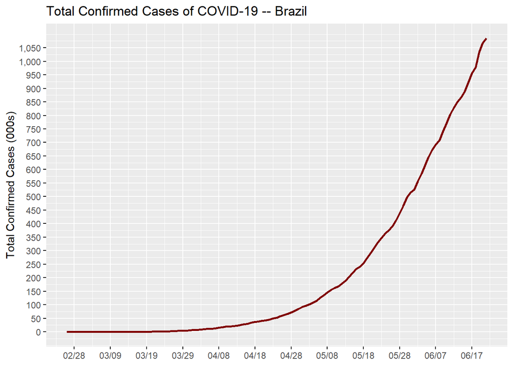

```r
# Total (cumulative) cases

max_casos_accum <- br_data %>%
  filter(reg == "Brasil") %>%
  group_by(date) %>%
  summarise(x = sum(cases_accum)) %>%
  ungroup()

gr_day_tot <- br_data %>%
  filter(date_d >= date_first_case & reg == "Brasil") %>%
  group_by(date_d) %>%
  summarise(dd = sum(cases_accum)) %>%
  ggline(x = "date_d",
         y = "dd",
         plot_type = "l",
         size = 1,
         color = "#800000FF",
         palette = "uchicago",
         title = "Total Confirmed Cases of COVID-19 -- Brazil",
         xlab = FALSE,
         ylab = "Total Confirmed Cases (000s)",
         ggtheme = theme_grey()) +
  scale_x_date(date_breaks = "10 days", date_labels = "%m/%d") +
  scale_y_continuous(breaks = seq(0, max(max_casos_accum$x) + 3000, 50000),
                     labels = number_format(scale = 0.001, big.mark = ","))

gr_day_tot
```

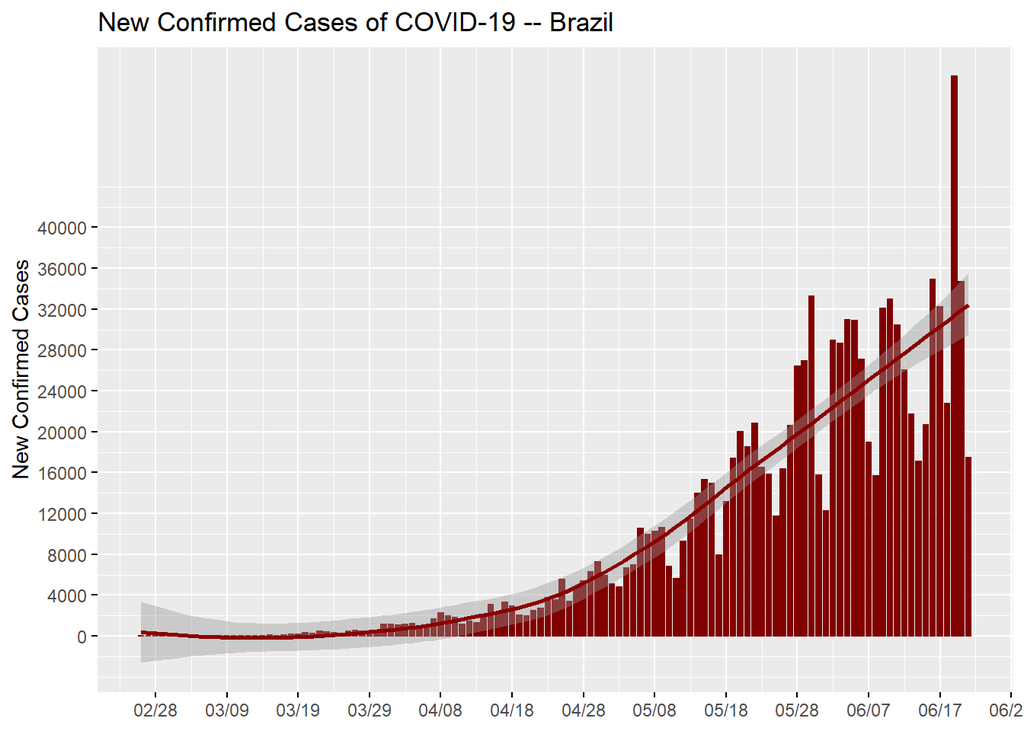

```r
# Daily New Cases

gr_day_new <- br_data %>%
  filter(date_d >= date_first_case & reg == "Brasil") %>%
  group_by(date_d) %>%
  ggbarplot(x = "date_d",
         y = "cases_new",
         color = "#800000FF",
         fill = "#800000FF",
         palette = "uchicago",
         title = "New Confirmed Cases of COVID-19 -- Brazil",
         xlab = FALSE,
         ylab = "New Confirmed Cases",
         ggtheme = theme_grey()) +
  geom_smooth(color = "darkred")+
  scale_x_date(date_breaks = "10 days", date_labels = "%m/%d") +
  scale_y_continuous(breaks = seq(0, 40000, 4000))

gr_day_new
```

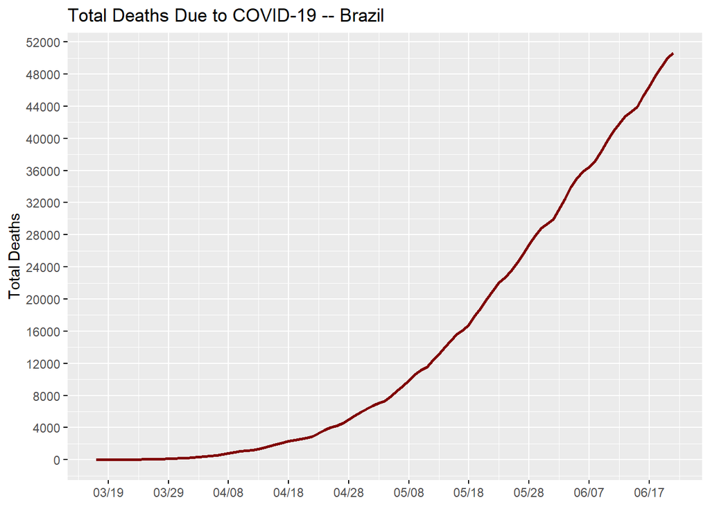

```r
# Cumulative Deaths

max_death_cumul <- br_data %>%
  group_by(date) %>%
  summarise(x = sum(deaths_accum)) %>%
  ungroup()

gr_death_tot <- br_data %>%
  filter(date_d >= date_first_death & reg == "Brasil") %>%
  group_by(date_d) %>%
  summarise(dd = sum(deaths_accum)) %>%
  ggline(x = "date_d",
         y = "dd",
         color = "#800000FF",
         plot_type = "l",
         size = 1,
         palette = "uchicago",
         title = "Total Deaths Due to COVID-19 -- Brazil",
         xlab = FALSE,
         ylab = "Total Deaths",
         ggtheme = theme_grey()) +
  scale_x_date(date_breaks = "10 days", date_labels = "%m/%d") +
  scale_y_continuous(breaks = seq(0, max(max_death_cumul$x) + 2000, 4000))

gr_death_tot
```

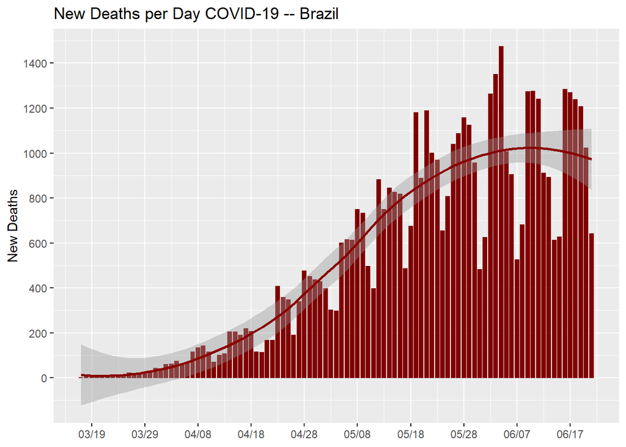

```r
# Daily New Deaths

gr_death_new <- br_data %>%
  filter(date_d >= date_first_death & reg == "Brasil") %>%
  group_by(date_d) %>%
  summarise(dd = sum(deaths_new)) %>%
  ggbarplot(x = "date_d",
         y = "dd",
         color = "#800000FF",
         fill = "#800000FF",
         palette = "uchicago",
         title = "New Deaths per Day COVID-19 -- Brazil",
         xlab = FALSE,
         ylab = "New Deaths",
         ggtheme = theme_grey()) +
  geom_smooth(color = "darkred")+
  scale_x_date(date_breaks = "10 days", date_labels = "%m/%d") +
  scale_y_continuous(breaks = seq(0, 2000, 200))

gr_death_new
```

# Comparison of Brazil with Other Countries

## Comparison Based on Counts of Confirmed Cases and Deaths

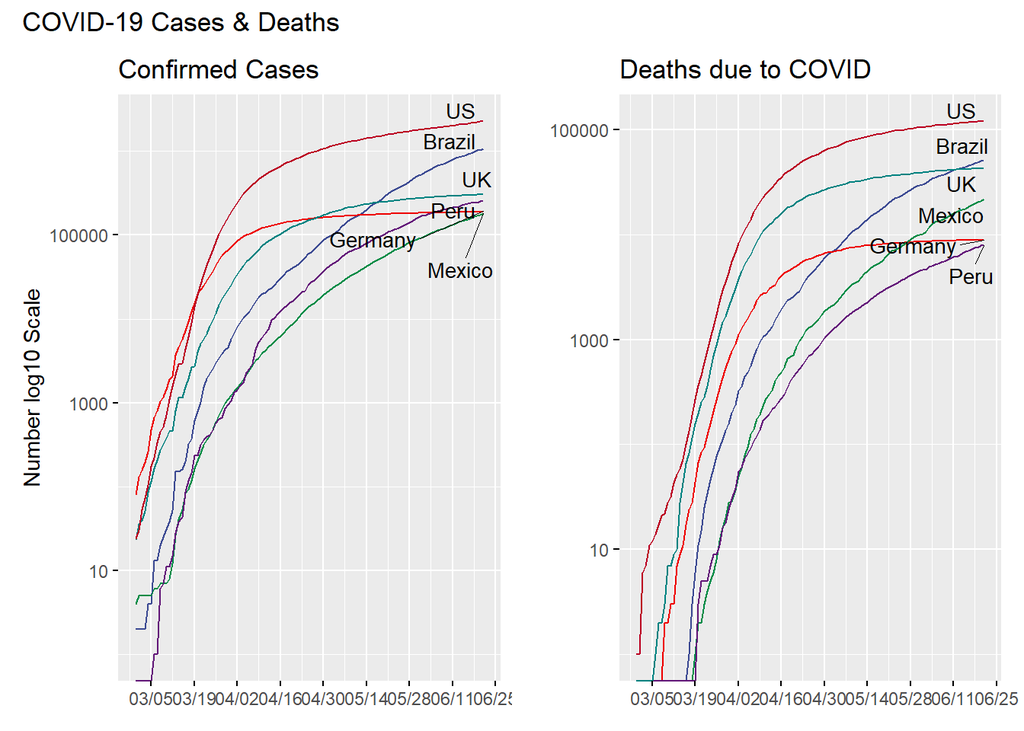

```r
covid_jhu <- readRDS(here("data", "covid_data_2020-06-22.rds"))

countries_interest <- c("Brazil", "Germany", "Mexico", "Peru", "UK", "US")

interest <- covid_jhu %>%
  # shorten name of UK
  mutate(country = ifelse(country == "United Kingdom", "UK", country)) %>%
  filter(country %in% countries_interest) %>%
  group_by(date, country) %>%
  summarise(cases = sum(cases),
            deaths = sum(deaths)) %>%

  ungroup()

## Confirmed Cases for Countries of Interest

gr_interest <- interest %>%
  select(country, date, cases) %>%
  filter(date > "2020/02/28") %>%
  mutate(country = fct_drop(country)) %>%
  ggline(x = "date",
         y = "cases",
         group = "country",
         color = "country",
         plot_type = "l",
         palette = "aaas",
         title = "Confirmed Cases",
         xlab = FALSE,
         ylab = "Number log10 Scale",
         legend = "none",
         repel = TRUE,
         show.line.label = TRUE,
         ggtheme = theme_gray())  +
  scale_x_date(date_breaks = "14 days", date_labels = "%m/%d") +
  scale_y_log10()

gr_interest_d <- interest %>%
  select(country, date, deaths) %>%
  filter(date > "2020/02/28") %>%
  mutate(country = fct_drop(country)) %>%
  ggline(x = "date",
         y = "deaths",
         group = "country",
         color = "country",
         plot_type = "l",
         palette = "aaas",
         title = "Deaths due to COVID",
         xlab = FALSE,
         ylab = "",
         legend = "none",
         repel = TRUE,
         show.line.label = TRUE,
         ggtheme = theme_gray())  +
  scale_x_date(date_breaks = "14 days", date_labels = "%m/%d") +
  scale_y_log10()

# daily increase graph

gr_di_c_int <- interest %>%
  group_by(country) %>%
  mutate(inc_c = deaths - lag(deaths)) %>%
  filter(date > "2020/03/01") %>%
  select(date, inc_c, country) %>%
  ggline(x = "date",
         y = "inc_c",
         plot_type = "l",
         group = "country",
         color = "country",
         palette = "uchicago",
         title = "Daily Increase in Deaths",
         xlab = FALSE,
         ylab = "Daily Increase in Deaths (000s)",
         legend = "none",
         repel = TRUE,
         ggtheme = theme_gray())  +
  scale_x_date(date_breaks = "21 days", date_labels = "%m/%d") +
  scale_y_continuous(labels = number_format(scale = 0.001, big.mark = ",")) +
  facet_wrap(facets = "country", scales = "free_y")

# print patchwork graphs
gr_interest + gr_interest_d +
  plot_annotation("COVID-19 Cases & Deaths")
```

Two disturbing trends appear in the above graphs. First, although Brazil started its rise in both the number of confirmed cases and deaths later than the United States, it has risen rapidly to become the country with the second-most cases and deaths (having surpassed the UK in the past two days). Brazil’s trajectory is still rising rather than stabilizing. The second disturbing trend is that all three Latin American countries in this list are the three whose growth in deaths and confirmed cases is still accelerating rather than leveling off.

These trends can be seen in a comparison of the daily increase in deaths among these six countries.

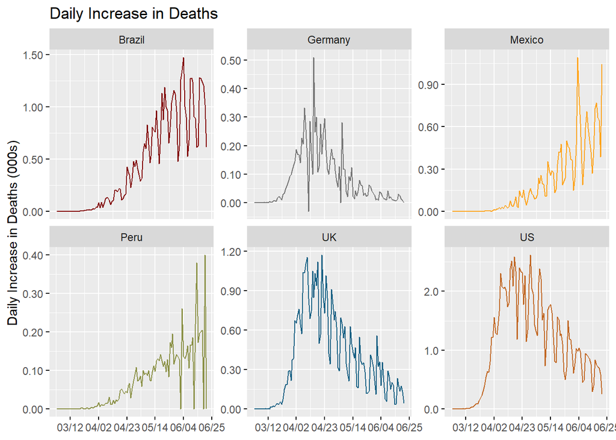

```r
gr_di_c_int
```

## Comparison of Confirmed Cases and Deaths Accounting for Population

Comparing countries based on raw counts of deaths and cases does not provide a totally fair comparison. These are countries of vastly different geographic sizes and populations. The following figure shows how these countries compare when the relative population of each country is taken into account. For population, I will use the World Bank’s population estimates for 2018 and I will create a new variable: cases or deaths per 100,000 population.

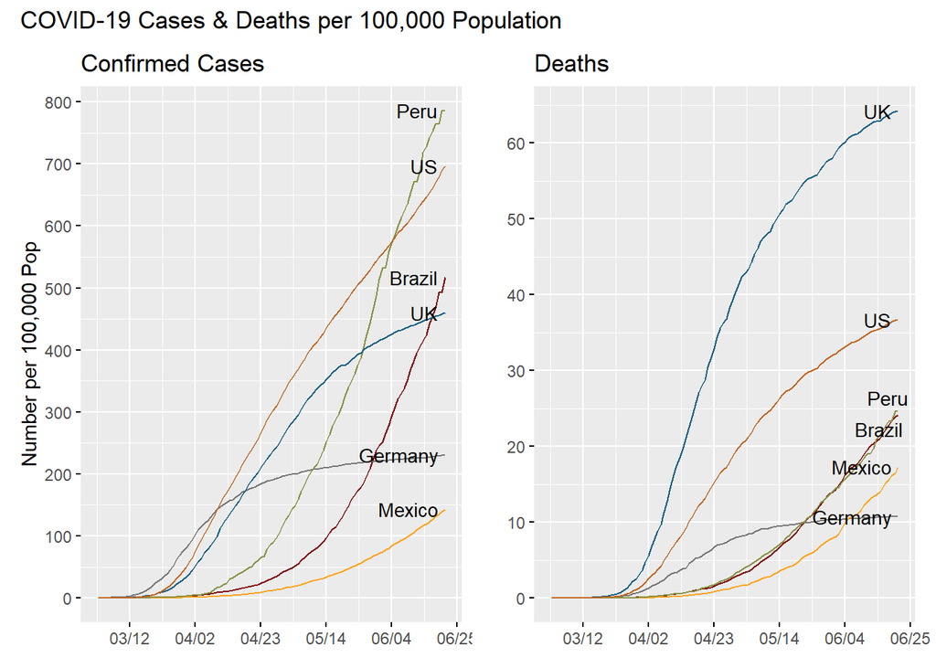

```r
# Get the World Bank population data from API_SP.POP.TOTL_DS2_en_csv_v2_887275.csv from the
# World Bank data website; adjust "United Kingdom" to "UK"

pop <- read_csv(glue(here(), "/data/total_pop_world_bank.csv"), col_names = FALSE, skip = 5) %>%
  select(country = X1, pop2018 = X63) %>%
  mutate(country = ifelse(country == "United Kingdom", "UK", country),
         country = ifelse(country == "United States", "US", country))

interest <- interest %>%
  left_join(pop, by = "country") %>%
  mutate(country = factor(country),
         cases_Mpop = cases * 100000 / pop2018,
         deaths_Mpop = deaths * 100000 / pop2018)

## Redo graph

g_conf_pop <- interest %>%
  select(country, date, cases_Mpop) %>%
  filter(date > "2020/03/01") %>%
  ggline(x = "date",
         y = "cases_Mpop",
         group = "country",
         color = "country",
         plot_type = "l",
         palette = "uchicago",
         title = "Confirmed Cases",
         xlab = FALSE,
         ylab = "Number per 100,000 Pop",
         legend = "none",
         repel = TRUE,
         show.line.label = TRUE,
         ggtheme = theme_gray()) +
  scale_x_date(date_breaks = "21 days", date_labels = "%m/%d") +
  scale_y_continuous(breaks = seq(0, 1000, 100))


g_death_pop <- interest %>%
  select(country, date, deaths_Mpop) %>%
  filter(date > "2020/03/01") %>%
  ggline(x = "date",
         y = "deaths_Mpop",
         group = "country",
         color = "country",
         plot_type = "l",
         palette = "uchicago",
         title = "Deaths",
         xlab = FALSE,
         ylab = "",
         legend = "none",
         repel = TRUE,
         show.line.label = TRUE,
         ggtheme = theme_gray()) +
  scale_x_date(date_breaks = "21 days", date_labels = "%m/%d") +
  scale_y_continuous(breaks = seq(0, 100, 10))

g_conf_pop + g_death_pop +
  plot_annotation("COVID-19 Cases & Deaths per 100,000 Population")
```

```r
br_last <- interest %>%
  filter(country == "Brazil") %>%
  slice_tail(n = 1) %>%
  select(cases_Mpop, deaths_Mpop)
```

# Doubling Time of COVID-19 Deaths

```r
double_death <- br_data %>%
  filter(date_d >= date_first_death & reg == "Brasil") %>%
  select(date_d, deaths_accum)

total_deaths <- double_death$deaths_accum[nrow(double_death)]

half_tot_deaths <- floor(total_deaths/2)
quarter_tot_deaths <- floor(half_tot_deaths/2)
eighth_tot_deaths <- floor(quarter_tot_deaths/2)


# Using total deaths of 40919 as of 1106 as current


date_8th <- double_death$date[double_death$deaths_accum > eighth_tot_deaths][1]
date_quart <- double_death$date[double_death$deaths_accum > quarter_tot_deaths][1]
date_half <- double_death$date[double_death$deaths_accum > half_tot_deaths][1]
date_tot <- double_death$date[double_death$deaths_accum == total_deaths][1]

dt_1 <- date_quart - date_8th
dt_2 <- date_half - date_quart
dt_3 <- date_tot - date_half

dt <- tibble(level = c(quarter_tot_deaths, half_tot_deaths, total_deaths),
             dbltime = c(dt_1, dt_2, dt_3))
kable(dt, caption = "COVID-19 Deaths--Doubling Time",
      col.names = c("Level", "Days from Previous Doubling")) %>%
  kable_styling(full_width = FALSE)
```

COVID-19 Deaths–Doubling Time

| Level | Days from Previous Doubling |
| --- | --- |
| 12654 | 12 days |
| 25308 | 14 days |
| 50617 | 25 days |

# Conclusion

The COVID-19 pandemic in Brazil is still in its first, ascendant phase. Brazil’s case load and the resulting deaths have not yet reached their peak. However, the doubling time of deaths indicate that the epidemic is slowing. When the first phase will end is still difficult to say. Part of the problem surrounding predictability of COVID-19 in Brazil is the quality of the data, which I discussed at length above.

[^1]: https://github.com/CSSEGISandData/COVID-19